# tidyverse overview

March 25th 2021 - Rendered at 2021-03-25 17:04:34

## While we wait…

1. Install R from cran.r-project.org
2. Install Rstudio from rstudio.com
3. Install the tidyverse with this R command: `install.packages("tidyverse")`
4. If you’d like to follow along, get the slides (.html) and/or code (.R): github.com/andrewGhazi/tidy_overview

## What is the tidyverse?

- A dialect of R
- A collection of R packages with a shared design philosophy
- Install it with this R command: `install.packages("tidyverse")`

## Why use the tidyverse?

- Shared design philosophy → inter-package consistency
- Focused on data science and statistical analysis
- Easy to learn, write, and read
- It’s ubiquitous

## Outline

- Core concepts
- Package overview
- End-to-end example
- Questions

[figure not shown]

## How to read these slides

- Lecture notes show up like this.

```r
print("Console output has two pound symbols in front.")
```

```
## [1] "Console output has two pound symbols in front."
```

```r
x = 5
```

- Assignment prints nothing.
- `package::function()` e.g. `dplyr::filter()`

## Load the tidyverse

The startup message lists loaded packages and overwritten functions.

```r
library(tidyverse)
```

## Core concepts

## Data frames

- Used to store ordered collections of variables

```r
diabetes
```

```
## # A tibble: 532 x 8
##    npreg   glu    bp  skin   bmi   ped   age diabetic
##    <dbl> <dbl> <dbl> <dbl> <dbl> <dbl> <dbl> <chr>
##  1     5    86    68    28  30.2 0.364    24 No
##  2     7   195    70    33  25.1 0.163    55 Yes
##  3     5    77    82    41  35.8 0.156    35 No
##  4     0   165    76    43  47.9 0.259    26 No
##  5     0   107    60    25  26.4 0.133    23 No
##  6     5    97    76    27  35.6 0.378    52 Yes
##  7     3    83    58    31  34.3 0.336    25 No
##  8     1   193    50    16  25.9 0.655    24 No
##  9     3   142    80    15  32.4 0.2      63 No
## 10     2   128    78    37  43.3 1.22     31 Yes
## # ... with 522 more rows
```

## tidy data

- Columns are variables
- Rows are observations

```
## # A tibble: 532 x 8
##    npreg   glu    bp  skin   bmi   ped   age diabetic
##    <dbl> <dbl> <dbl> <dbl> <dbl> <dbl> <dbl> <chr>
##  1     5    86    68    28  30.2 0.364    24 No
##  2     7   195    70    33  25.1 0.163    55 Yes
##  3     5    77    82    41  35.8 0.156    35 No
##  4     0   165    76    43  47.9 0.259    26 No
##  5     0   107    60    25  26.4 0.133    23 No
##  6     5    97    76    27  35.6 0.378    52 Yes
##  7     3    83    58    31  34.3 0.336    25 No
##  8     1   193    50    16  25.9 0.655    24 No
##  9     3   142    80    15  32.4 0.2      63 No
## 10     2   128    78    37  43.3 1.22     31 Yes
## # ... with 522 more rows
```

## tidyverse functions

- data frame in, data frame out
- Function names are *verbs*
  - e.g. `filter`, `arrange`, `mutate`

## Pipes

- Pipes look like this: `%>%`
- They take the input from the left side, and hand it to the right side:

```r
c(1,2,3,4) %>% mean
```

```
## [1] 2.5
```

- Verbalize as: “and then”.
- “Create this vector and then take the mean”.

## Pipe example

Why are pipes useful?

## Pipe example

Why are pipes useful?

[figure not shown]

## Pipe example

Why are pipes useful?

[figure not shown]

## Pipe example

Compare two ways of doing the same thing:

```r
input = "potatoes"

stick(mash(boil(input)), where = 'stew')
```

```
## [1] "stewed, mashed, boiled potatoes"
```

## Pipe example

Compare two ways of doing the same thing:

```r
input = "potatoes"

stick(mash(boil(input)), where = 'stew')
```

```
## [1] "stewed, mashed, boiled potatoes"
```

```r
input %>% boil() %>% mash() %>% stick(where = 'stew')
```

```
## [1] "stewed, mashed, boiled potatoes"
```

## Pipe example

Why are pipes useful?

Because chained verbs look like English sentences.

```r
input %>%
  boil() %>%
  mash() %>%
  stick(where = 'stew')
```

- Piped code is easier to write *and easier to read*.
- Keyboard shortcut: `ctrl + shift + M`

## package overview

## Import - `readr`

- Get the data into R as a data frame.
- Read data from a file on your computer or from a URL
- `read_csv()`, `read_tsv()`
- related package: `readxl`
- Read in the diabetes example dataset:

```r
data_path = "data/diabetes.tsv"
diabetes = read_tsv(data_path)
```

[figure not shown]

## Manipulate - `dplyr`

- Package for basic data manipulation
- Most important functions: `filter()`, `select()`, `arrange()`, `mutate()`, `group_by()`, `summarise()`
- Focused on data frames

## `dplyr::filter()`

- Subset rows by a condition

```r
diabetes %>%
  filter(npreg == 0)
```

```
## # A tibble: 77 x 8
##    npreg   glu    bp  skin   bmi   ped   age diabetic
##    <dbl> <dbl> <dbl> <dbl> <dbl> <dbl> <dbl> <chr>
##  1     0   165    76    43  47.9 0.259    26 No
##  2     0   107    60    25  26.4 0.133    23 No
##  3     0   137    40    35  43.1 2.29     33 Yes
##  4     0   139    62    17  22.1 0.207    21 No
##  5     0   101    64    17  21   0.252    21 No
##  6     0   140    65    26  42.6 0.431    24 Yes
##  7     0   121    66    30  34.3 0.203    33 Yes
##  8     0   102    86    17  29.3 0.695    27 No
##  9     0   119    66    27  38.8 0.259    22 No
## 10     0    86    68    32  35.8 0.238    25 No
## # ... with 67 more rows
```

## `dplyr::filter()`

- Subset rows by a condition

```r
diabetes %>%
  filter(bmi > 30)
```

```
## # A tibble: 342 x 8
##    npreg   glu    bp  skin   bmi   ped   age diabetic
##    <dbl> <dbl> <dbl> <dbl> <dbl> <dbl> <dbl> <chr>
##  1     5    86    68    28  30.2 0.364    24 No
##  2     5    77    82    41  35.8 0.156    35 No
##  3     0   165    76    43  47.9 0.259    26 No
##  4     5    97    76    27  35.6 0.378    52 Yes
##  5     3    83    58    31  34.3 0.336    25 No
##  6     3   142    80    15  32.4 0.2      63 No
##  7     2   128    78    37  43.3 1.22     31 Yes
##  8     0   137    40    35  43.1 2.29     33 Yes
##  9     9   154    78    30  30.9 0.164    45 No
## 10     1   189    60    23  30.1 0.398    59 Yes
## # ... with 332 more rows
```

## `dplyr::select()`

- Subset columns
- Choose columns by name, index, or condition

```r
diabetes %>%
  select(diabetic, npreg, age)
```

```
## # A tibble: 532 x 3
##    diabetic npreg   age
##    <chr>    <dbl> <dbl>
##  1 No           5    24
##  2 Yes          7    55
##  3 No           5    35
##  4 No           0    26
##  5 No           0    23
##  6 Yes          5    52
##  7 No           3    25
##  8 No           1    24
##  9 No           3    63
## 10 Yes          2    31
## # ... with 522 more rows
```

## `dplyr::select()`

- Subset columns
- Choose columns by name, index, or condition

```r
diabetes %>%
  select(8, 1, 7)
```

```
## # A tibble: 532 x 3
##    diabetic npreg   age
##    <chr>    <dbl> <dbl>
##  1 No           5    24
##  2 Yes          7    55
##  3 No           5    35
##  4 No           0    26
##  5 No           0    23
##  6 Yes          5    52
##  7 No           3    25
##  8 No           1    24
##  9 No           3    63
## 10 Yes          2    31
## # ... with 522 more rows
```

## `dplyr::select()`

- Subset columns
- Choose columns by name, index, or condition

```r
diabetes %>%
  select(starts_with('b'), matches('diab'))
```

```
## # A tibble: 532 x 3
##       bp   bmi diabetic
##    <dbl> <dbl> <chr>
##  1    68  30.2 No
##  2    70  25.1 Yes
##  3    82  35.8 No
##  4    76  47.9 No
##  5    60  26.4 No
##  6    76  35.6 Yes
##  7    58  34.3 No
##  8    50  25.9 No
##  9    80  32.4 No
## 10    78  43.3 Yes
## # ... with 522 more rows
```

## `dplyr::arrange()`

- Reorder rows by a variable

```r
diabetes %>% arrange(bmi)
```

```
## # A tibble: 532 x 8
##    npreg   glu    bp  skin   bmi   ped   age diabetic
##    <dbl> <dbl> <dbl> <dbl> <dbl> <dbl> <dbl> <chr>
##  1     1    97    64    19  18.2 0.299    21 No
##  2     1    97    70    15  18.2 0.147    21 No
##  3     3    99    80    11  19.3 0.284    30 No
##  4     1   103    80    11  19.4 0.491    22 No
##  5     1    92    62    25  19.5 0.482    25 No
##  6     1   100    74    12  19.5 0.149    28 No
##  7     1    95    66    13  19.6 0.334    25 No
##  8     6   129    90     7  19.6 0.582    60 No
##  9     0   105    68    22  20   0.236    22 No
## 10     2    68    62    13  20.1 0.257    23 No
## # ... with 522 more rows
```

## `dplyr::arrange()`

- Reorder rows by a variable

```r
diabetes %>% arrange(desc(age))
```

```
## # A tibble: 532 x 8
##    npreg   glu    bp  skin   bmi   ped   age diabetic
##    <dbl> <dbl> <dbl> <dbl> <dbl> <dbl> <dbl> <chr>
##  1     9   134    74    33  25.9 0.46     81 No
##  2     4   145    82    18  32.5 0.235    70 Yes
##  3     5   103   108    37  39.2 0.305    65 No
##  4     3   142    80    15  32.4 0.2      63 No
##  5     4   132    86    31  28   0.419    63 No
##  6    10   101    76    48  32.9 0.171    63 No
##  7    12   121    78    17  26.5 0.259    62 No
##  8     2   197    70    99  34.7 0.575    62 Yes
##  9     7   142    60    33  28.8 0.687    61 No
## 10     8   181    68    36  30.1 0.615    60 Yes
## # ... with 522 more rows
```

Quiz: What’s the highest blood pressure observed in this data? (hint: desc())

## `dplyr::mutate()`

- Add new columns
- Structure:

```r
input_df %>%
  mutate(col_name = col_values)
```

## `dplyr::mutate()`

- Add new columns
- Example: add an index

```r
diabetes %>%
  mutate(index = 1:532)
```

```
## # A tibble: 532 x 9
##    npreg   glu    bp  skin   bmi   ped   age diabetic index
##    <dbl> <dbl> <dbl> <dbl> <dbl> <dbl> <dbl> <chr>    <int>
##  1     5    86    68    28  30.2 0.364    24 No           1
##  2     7   195    70    33  25.1 0.163    55 Yes          2
##  3     5    77    82    41  35.8 0.156    35 No           3
##  4     0   165    76    43  47.9 0.259    26 No           4
##  5     0   107    60    25  26.4 0.133    23 No           5
##  6     5    97    76    27  35.6 0.378    52 Yes          6
##  7     3    83    58    31  34.3 0.336    25 No           7
##  8     1   193    50    16  25.9 0.655    24 No           8
##  9     3   142    80    15  32.4 0.2      63 No           9
## 10     2   128    78    37  43.3 1.22     31 Yes         10
## # ... with 522 more rows
```

## `dplyr::mutate()`

- Refer to other columns by name
- Example: Calculate birth year as a function of age

```r
diabetes %>%
  mutate(birth_year = 2021 - age)
```

```
## # A tibble: 532 x 9
##    npreg   glu    bp  skin   bmi   ped   age diabetic birth_year
##    <dbl> <dbl> <dbl> <dbl> <dbl> <dbl> <dbl> <chr>         <dbl>
##  1     5    86    68    28  30.2 0.364    24 No             1997
##  2     7   195    70    33  25.1 0.163    55 Yes            1966
##  3     5    77    82    41  35.8 0.156    35 No             1986
##  4     0   165    76    43  47.9 0.259    26 No             1995
##  5     0   107    60    25  26.4 0.133    23 No             1998
##  6     5    97    76    27  35.6 0.378    52 Yes            1969
##  7     3    83    58    31  34.3 0.336    25 No             1996
##  8     1   193    50    16  25.9 0.655    24 No             1997
##  9     3   142    80    15  32.4 0.2      63 No             1958
## 10     2   128    78    37  43.3 1.22     31 Yes            1990
## # ... with 522 more rows
```

## `dplyr::mutate()`

- Add new columns
- Example: Calculate birth year as a function of age

```r
diabetes %>%
  mutate(birth_year = 2021 - age,
         is_mother = npreg > 0)
```

```
## # A tibble: 532 x 10
##    npreg   glu    bp  skin   bmi   ped   age diabetic birth_year is_mother
##    <dbl> <dbl> <dbl> <dbl> <dbl> <dbl> <dbl> <chr>         <dbl> <lgl>
##  1     5    86    68    28  30.2 0.364    24 No             1997 TRUE
##  2     7   195    70    33  25.1 0.163    55 Yes            1966 TRUE
##  3     5    77    82    41  35.8 0.156    35 No             1986 TRUE
##  4     0   165    76    43  47.9 0.259    26 No             1995 FALSE
##  5     0   107    60    25  26.4 0.133    23 No             1998 FALSE
##  6     5    97    76    27  35.6 0.378    52 Yes            1969 TRUE
##  7     3    83    58    31  34.3 0.336    25 No             1996 TRUE
##  8     1   193    50    16  25.9 0.655    24 No             1997 TRUE
##  9     3   142    80    15  32.4 0.2      63 No             1958 TRUE
## 10     2   128    78    37  43.3 1.22     31 Yes            1990 TRUE
## # ... with 522 more rows
```

## `dplyr::group_by()`

- Group a data frame
- Example: diabetic vs non-diabetic:

```r
diabetes %>%
  group_by(diabetic)
```

```
## # A tibble: 532 x 8
## # Groups:   diabetic [2]
##    npreg   glu    bp  skin   bmi   ped   age diabetic
##    <dbl> <dbl> <dbl> <dbl> <dbl> <dbl> <dbl> <chr>
##  1     5    86    68    28  30.2 0.364    24 No
##  2     7   195    70    33  25.1 0.163    55 Yes
##  3     5    77    82    41  35.8 0.156    35 No
##  4     0   165    76    43  47.9 0.259    26 No
##  5     0   107    60    25  26.4 0.133    23 No
##  6     5    97    76    27  35.6 0.378    52 Yes
##  7     3    83    58    31  34.3 0.336    25 No
##  8     1   193    50    16  25.9 0.655    24 No
##  9     3   142    80    15  32.4 0.2      63 No
## 10     2   128    78    37  43.3 1.22     31 Yes
## # ... with 522 more rows
```

## `dplyr::summarise()`

- Compute summary values by group

```r
diabetes %>%
  group_by(diabetic) %>%
  summarise(mean_age = mean(age))
```

```
## # A tibble: 2 x 2
##   diabetic mean_age
## * <chr>       <dbl>
## 1 No           29.2
## 2 Yes          36.4
```

## `dplyr::summarise()`

- Compute summary values by group

```r
diabetes %>%
  group_by(diabetic) %>%
  summarise(mean_age = mean(age),
            group_size = n())
```

```
## # A tibble: 2 x 3
##   diabetic mean_age group_size
## * <chr>       <dbl>      <int>
## 1 No           29.2        355
## 2 Yes          36.4        177
```

## `dplyr::summarise()`

- You can group by multiple variables

```r
diabetes %>%
  mutate(is_mother = npreg > 0) %>%
  group_by(diabetic, is_mother)
```

```
## # A tibble: 532 x 9
## # Groups:   diabetic, is_mother [4]
##    npreg   glu    bp  skin   bmi   ped   age diabetic is_mother
##    <dbl> <dbl> <dbl> <dbl> <dbl> <dbl> <dbl> <chr>    <lgl>
##  1     5    86    68    28  30.2 0.364    24 No       TRUE
##  2     7   195    70    33  25.1 0.163    55 Yes      TRUE
##  3     5    77    82    41  35.8 0.156    35 No       TRUE
##  4     0   165    76    43  47.9 0.259    26 No       FALSE
##  5     0   107    60    25  26.4 0.133    23 No       FALSE
##  6     5    97    76    27  35.6 0.378    52 Yes      TRUE
##  7     3    83    58    31  34.3 0.336    25 No       TRUE
##  8     1   193    50    16  25.9 0.655    24 No       TRUE
##  9     3   142    80    15  32.4 0.2      63 No       TRUE
## 10     2   128    78    37  43.3 1.22     31 Yes      TRUE
## # ... with 522 more rows
```

## `dplyr::summarise()`

- You can group by multiple variables

```r
diabetes %>%
  mutate(is_mother = npreg > 0) %>%
  group_by(diabetic, is_mother) %>%
  summarise(mean_age = mean(age))
```

```
## # A tibble: 4 x 3
## # Groups:   diabetic [2]
##   diabetic is_mother mean_age
##   <chr>    <lgl>        <dbl>
## 1 No       FALSE         25.1
## 2 No       TRUE          29.9
## 3 Yes      FALSE         26.8
## 4 Yes      TRUE          38.1
```

## Visualize - `ggplot2`

- “Grammar of graphics”
- Core concepts:
  - Variables from tidy input data
  - Aesthetic mappings between variables and graphical elements: `aes()`
  - Add geometric objects to represent data via `geom_*()` e.g. `geom_point()`


## Visualize - `ggplot2` example

- Tidy input, aesthetic mapping, and a geom

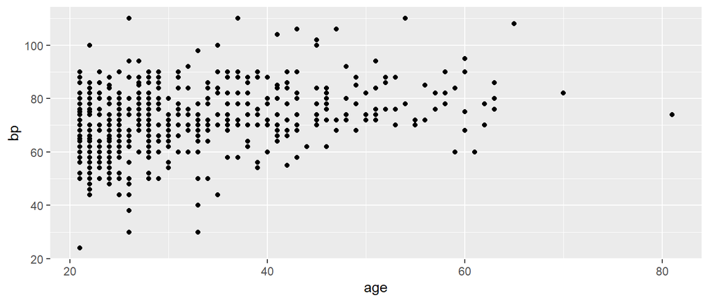

```r
diabetes %>%
  ggplot(mapping = aes(x = age, y = bp)) +
  geom_point()
```

## Visualize - `ggplot2` example

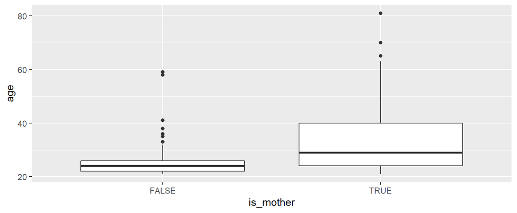

```r
diabetes %>%
  mutate(is_mother = npreg > 0) %>%
  ggplot(aes(is_mother, age)) +
  geom_boxplot()
```

## Visualize - `ggplot2`’s suite of geoms

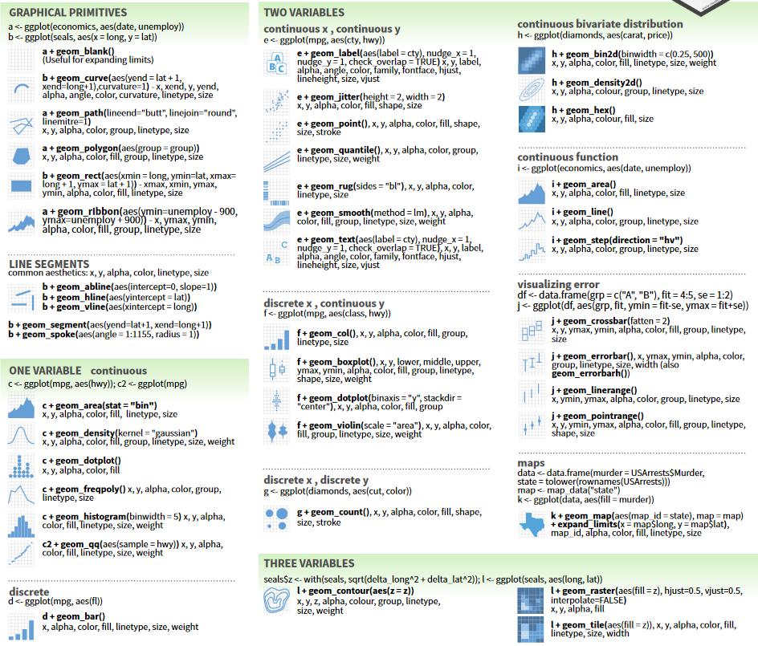

## Report - `rmarkdown`

- Communicate analysis results
- Easily interweave notes, code, plots, and \(\LaTeX\) in a single file
- Render as reports (.docx, .pdf, .html), slides (.html, .ppt), or web applications (Shiny)
- Rmd + Github = Digital lab notebook
- Demonstration at end of session 1 if there’s time

## COVID-19 example

## COVID-19 data

- New York Times COVID-19 data on Github
- https://github.com/nytimes/covid-19-data
- Provides COVID-19 data by county, state, and nation-wide

## Example: US COVID-19 state-level data

```r
nyt_url = "https://raw.githubusercontent.com/nytimes/covid-19-data/master/us-states.csv"
state_covid = read_csv(nyt_url)
```

## Example: Import state-level COVID-19 data

- Look at the data

```r
state_covid
```

```
## # A tibble: 21,299 x 5
##    date       state      fips  cases deaths
##    <date>     <chr>      <chr> <dbl>  <dbl>
##  1 2020-01-21 Washington 53        1      0
##  2 2020-01-22 Washington 53        1      0
##  3 2020-01-23 Washington 53        1      0
##  4 2020-01-24 Illinois   17        1      0
##  5 2020-01-24 Washington 53        1      0
##  6 2020-01-25 California 06        1      0
##  7 2020-01-25 Illinois   17        1      0
##  8 2020-01-25 Washington 53        1      0
##  9 2020-01-26 Arizona    04        1      0
## 10 2020-01-26 California 06        2      0
## # ... with 21,289 more rows
```

## Example: COVID-19 in California

- Plot one state over time

```r
state_covid %>%
  filter(state == "California") %>%
  ggplot(aes(date, deaths)) +
  geom_line()
```

- What will the output of this command look like?

## Example: COVID-19 in California

- Plot one state over time

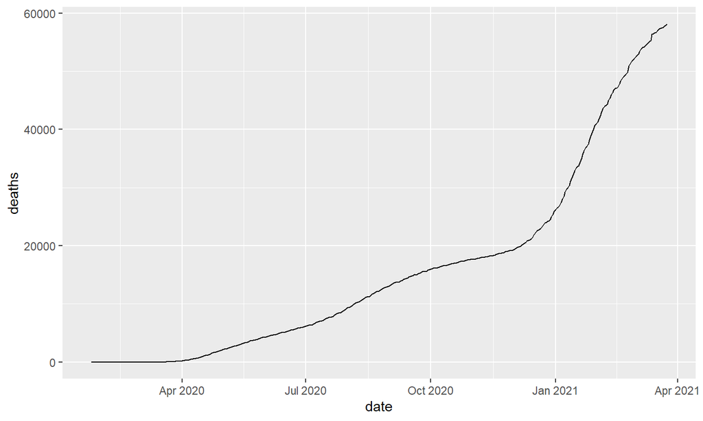

```r
state_covid %>%
  filter(state == "California") %>%
  ggplot(aes(date, deaths)) +
  geom_line()
```

## Example: COVID-19 in California

- Want to define the CHANGE in deaths

```r
state_covid %>%
  filter(state == "California", deaths > 0)
```

```
## # A tibble: 386 x 5
##    date       state      fips  cases deaths
##    <date>     <chr>      <chr> <dbl>  <dbl>
##  1 2020-03-04 California 06       55      1
##  2 2020-03-05 California 06       67      1
##  3 2020-03-06 California 06       81      1
##  4 2020-03-07 California 06      100      1
##  5 2020-03-08 California 06      112      1
##  6 2020-03-09 California 06      172      2
##  7 2020-03-10 California 06      179      3
##  8 2020-03-11 California 06      202      4
##  9 2020-03-12 California 06      252      4
## 10 2020-03-13 California 06      320      5
## # ... with 376 more rows
```

## Example: COVID-19 in California

- Define daily added deaths using `diff()`

```r
state_covid %>%
  filter(state == "California") %>%
  mutate(new_deaths = diff(deaths))
```

## That didn’t work

- Define daily added deaths using `diff()`

```r
state_covid %>%
  filter(state == "California") %>%
  mutate(new_deaths = diff(deaths))
```

```
## Error: Problem with `mutate()` input `new_deaths`.
## x Input `new_deaths` can't be recycled to size 425.
## i Input `new_deaths` is `diff(deaths)`.
## i Input `new_deaths` must be size 425 or 1, not 424.
```

## The fix

- `diff()` returns a vector that’s one element too short – tack on the first observation at the start.

```r
state_covid %>%
  filter(state == "California") %>%
  mutate(new_deaths = c(deaths[1], diff(deaths)))
```

```
## # A tibble: 425 x 6
##    date       state      fips  cases deaths new_deaths
##    <date>     <chr>      <chr> <dbl>  <dbl>      <dbl>
##  1 2020-01-25 California 06        1      0          0
##  2 2020-01-26 California 06        2      0          0
##  3 2020-01-27 California 06        2      0          0
##  4 2020-01-28 California 06        2      0          0
##  5 2020-01-29 California 06        2      0          0
##  6 2020-01-30 California 06        2      0          0
##  7 2020-01-31 California 06        3      0          0
##  8 2020-02-01 California 06        3      0          0
##  9 2020-02-02 California 06        6      0          0
## 10 2020-02-03 California 06        6      0          0
## # ... with 415 more rows
```

## Example: New deaths over time

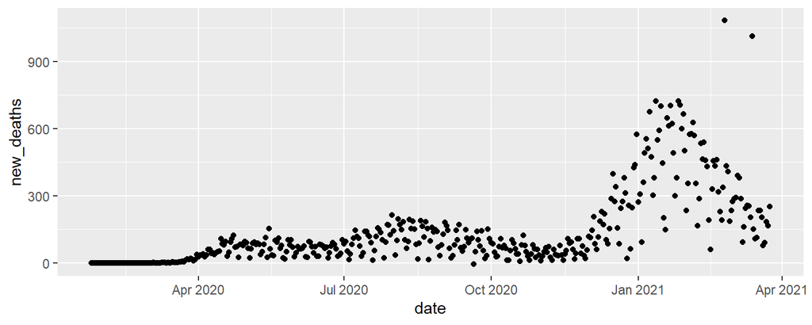

```r
state_covid %>%
  filter(state == "California") %>%
  mutate(new_deaths = c(deaths[1], diff(deaths))) %>%
  ggplot(aes(date, new_deaths)) +
  geom_point()
```

## Example: Adding bells and whistles to a plot

```r
state_covid %>%
  filter(state == "California") %>%
  mutate(new_deaths = c(deaths[1], diff(deaths))) %>%
  ggplot(aes(date, new_deaths)) +
  geom_point() +
  geom_smooth(method = "loess", span = .2) +
  labs(title = "Daily new deaths in California",
       y = "New Deaths",
       caption = "Data from the New York Times: https://github.com/nytimes/covid-19-data") +
  theme_bw()
```

## Example: COVID-19 in California

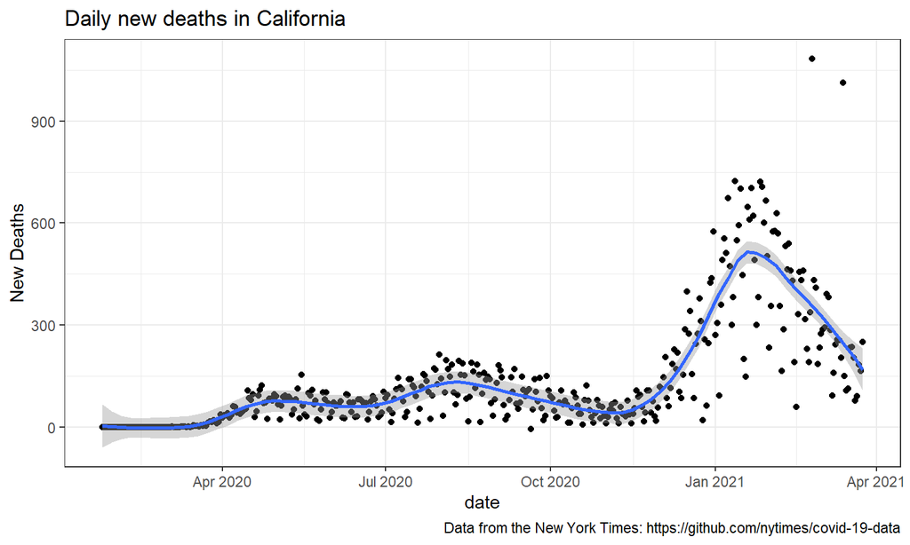

- Further enhancement with a trendline, labels, and theme
- Try plotting several states with different colors (hints: use `%in%` and `aes(color = ...)`)

## Example: US COVID-19

- What states had the highest daily new deaths?

## Example: US COVID-19

- What states had the highest daily new deaths?
- What do we need to do?

## Example: US COVID-19

- What was the highest daily increase in death in any state?

```r
state_covid %>%
  group_by(state) %>%
  mutate(new_deaths = c(deaths[1], diff(deaths))) %>%
  summarise(state_max = max(new_deaths)) %>%
  arrange(desc(state_max))
```

```
## # A tibble: 55 x 2
##    state        state_max
##    <chr>            <dbl>
##  1 Ohio              2559
##  2 New Jersey        1877
##  3 Indiana           1546
##  4 Texas             1202
##  5 California        1084
##  6 New York          1036
##  7 Georgia            466
##  8 Pennsylvania       401
##  9 Arizona            390
## 10 Virginia           383
## # ... with 45 more rows
```

- Note: `mutate()` is aware of groups!

## Before switching to RStudio…

## How to get help

- To look at the documentation for any function, use `?` or `help()`
  - `?summarise`
  - How to read help: https://socviz.co/appendix.html#a-little-more-about-r
- Package-specific walkthroughs: `vignette(package = "dplyr")`
- [R tag on Stats Stack Exchange - stats.stackexchange.com](https://stats.stackexchange.com/questions/tagged/r)

## Resources

- [R for Data Science - https://r4ds.had.co.nz/](https://r4ds.had.co.nz/)
- [Cheat Sheets - https://rstudio.com/resources/cheatsheets/](https://rstudio.com/resources/cheatsheets/)
- [Tidy Tuesday - Weekly analysis screencasts](https://github.com/rfordatascience/tidytuesday) [on youtube](https://www.youtube.com/playlist?list=PL19ev-r1GBwkuyiwnxoHTRC8TTqP8OEi8)

## Questions?

## Day 2

## `purrr`

- Functional programming

## `map()`

- Apply a function to each element of a list
- Example:

```r
map(1:3, sqrt)
```

```
## [[1]]
## [1] 1
##
## [[2]]
## [1] 1.414214
##
## [[3]]
## [1] 1.732051
```

## `map()`

- Apply a function to each element of a list
- Example:

```r
map(1:3, sqrt)
```

```
## [[1]]
## [1] 1
##
## [[2]]
## [1] 1.414214
##
## [[3]]
## [1] 1.732051
```

```r
map(datasets, ml_algorithm)
```

## Anonymous functions

- Tilde + `.x`
- Use to easily define single-use functions

## `map_*()` variants

- `map()` always returns a list
- Variants return a vector of a specific type

```r
map_dbl(1:5, ~.x^2 + 1)
```

```
## [1]  2  5 10 17 26
```

```r
map_lgl(1:5, ~.x == 3)
```

```
## [1] FALSE FALSE  TRUE FALSE FALSE
```

```r
map_chr(letters[1:5], ~paste0(rep(.x, 3), collapse=''))
```

```
## [1] "aaa" "bbb" "ccc" "ddd" "eee"
```

## purrr example: run many models

- Define each combination of two explanatory variables

```r
formula_df = names(diabetes)[1:7] %>%
  combn(m = 2) %>%
  t %>%
  as_tibble %>%
  set_names(c('x1', 'x2')) %>%
  mutate(formula = paste("diabetic ~ ", x1, " + ", x2, sep = ''))
formula_df
```

```
## # A tibble: 21 x 3
##    x1    x2    formula
##    <chr> <chr> <chr>
##  1 npreg glu   diabetic ~ npreg + glu
##  2 npreg bp    diabetic ~ npreg + bp
##  3 npreg skin  diabetic ~ npreg + skin
##  4 npreg bmi   diabetic ~ npreg + bmi
##  5 npreg ped   diabetic ~ npreg + ped
##  6 npreg age   diabetic ~ npreg + age
##  7 glu   bp    diabetic ~ glu + bp
##  8 glu   skin  diabetic ~ glu + skin
##  9 glu   bmi   diabetic ~ glu + bmi
## 10 glu   ped   diabetic ~ glu + ped
## # ... with 11 more rows
```

## purrr example: run many models

- Run a logistic regression on each combination of explanatory variables

```r
formula_df %>%
  mutate(glm_result = map(formula,
                          ~glm(.x, data = diabetes, family = 'binomial')))
```

## purrr example: run many models

- Extract the AIC of each model fit

```r
formula_df %>%
  mutate(glm_result = map(formula,
                          ~glm(.x, data = diabetes, family = 'binomial')),
         aic = map_dbl(lm_result,
                       ~.x$aic))
```

## purrr example: run many models

- See which model had the lowest AIC

```r
formula_df %>%
  mutate(glm_result = map(formula,
                          ~glm(.x, data = diabetes, family = 'binomial')),
         aic = map_dbl(lm_result,
                       ~.x$aic)) %>%
  arrange(aic)
```

## Organize - `tidyr`

- `pivot_longer()` and `pivot_wider()`
- `separate()` and `unite()`

## Data tidying example: WHO TB data

- WHO tuberculosis case data
- realistically messy!
- Try running these commands:

```r
?tidyr::who
dim(who)
names(who)
who[1:5, 1:8]
who
```

- We will tidy this data in 5 steps

## WHO TB column names

- First part: “new” or “old”
- Second part: TB type (relapse, extrapulmonary, smear-positive, smear-negative)
- Third part: Sex and age group (e.g. f2534)

## TB tidying 1/5: pivot wide to long

```r
who1 = who %>%
  pivot_longer(new_sp_m014:newrel_f65,
               names_to = "key",
               values_to = "values",
               values_drop_na = TRUE)
who1
```

```
## # A tibble: 76,046 x 6
##    country     iso2  iso3   year key          values
##    <chr>       <chr> <chr> <int> <chr>         <int>
##  1 Afghanistan AF    AFG    1997 new_sp_m014       0
##  2 Afghanistan AF    AFG    1997 new_sp_m1524     10
##  3 Afghanistan AF    AFG    1997 new_sp_m2534      6
##  4 Afghanistan AF    AFG    1997 new_sp_m3544      3
##  5 Afghanistan AF    AFG    1997 new_sp_m4554      5
##  6 Afghanistan AF    AFG    1997 new_sp_m5564      2
##  7 Afghanistan AF    AFG    1997 new_sp_m65        0
##  8 Afghanistan AF    AFG    1997 new_sp_f014       5
##  9 Afghanistan AF    AFG    1997 new_sp_f1524     38
## 10 Afghanistan AF    AFG    1997 new_sp_f2534     36
## # ... with 76,036 more rows
```

## TB tidying 2/5: fix inconsistent names

```r
who2 = who1 %>%
  mutate(key = str_replace(key, "newrel", "new_rel"))
who2
```

```
## # A tibble: 76,046 x 6
##    country     iso2  iso3   year key          values
##    <chr>       <chr> <chr> <int> <chr>         <int>
##  1 Afghanistan AF    AFG    1997 new_sp_m014       0
##  2 Afghanistan AF    AFG    1997 new_sp_m1524     10
##  3 Afghanistan AF    AFG    1997 new_sp_m2534      6
##  4 Afghanistan AF    AFG    1997 new_sp_m3544      3
##  5 Afghanistan AF    AFG    1997 new_sp_m4554      5
##  6 Afghanistan AF    AFG    1997 new_sp_m5564      2
##  7 Afghanistan AF    AFG    1997 new_sp_m65        0
##  8 Afghanistan AF    AFG    1997 new_sp_f014       5
##  9 Afghanistan AF    AFG    1997 new_sp_f1524     38
## 10 Afghanistan AF    AFG    1997 new_sp_f2534     36
## # ... with 76,036 more rows
```

## TB tidying 3/5: separate identifier components

```r
who3 = who2 %>%
  separate(key, into = c("newold", "tb_type", "sexage"))
```

## TB tidying 4/5: separate sex and age group

```r
who4 = who3 %>%
  separate(sexage, into = c("sex", "age_group"), sep = 1)
```

## TB tidying 5/5: remove redundant columns

```r
who_final = who4 %>%
  select(-newold, -matches("iso"))
```

## TB tidying: Final command

```r
tidyr::who %>%
  pivot_longer(new_sp_m014:newrel_f65,
               names_to = "key",
               values_to = "values",
               values_drop_na = TRUE) %>%
  mutate(key = str_replace(key, "newrel", "new_rel")) %>%
  separate(key, into = c("newold", "tb_type", "sexage")) %>%
  separate(sexage, into = c("sex", "age_group"), sep = 1) %>%
  select(-newold, -matches("iso"))
```

```
## # A tibble: 76,046 x 6
##    country      year tb_type sex   age_group values
##    <chr>       <int> <chr>   <chr> <chr>      <int>
##  1 Afghanistan  1997 sp      m     014            0
##  2 Afghanistan  1997 sp      m     1524          10
##  3 Afghanistan  1997 sp      m     2534           6
##  4 Afghanistan  1997 sp      m     3544           3
##  5 Afghanistan  1997 sp      m     4554           5
##  6 Afghanistan  1997 sp      m     5564           2
##  7 Afghanistan  1997 sp      m     65             0
##  8 Afghanistan  1997 sp      f     014            5
##  9 Afghanistan  1997 sp      f     1524          38
## 10 Afghanistan  1997 sp      f     2534          36
## # ... with 76,036 more rows
```

## Joins if there’s time

## Everything else

- `forcats` - work with factors
- `stringr` - work with strings
- `lubridate` - work with dates
- `tidymodels` - work with stats/ML algorithms
- `reticulate` - work with Python

## How to get help

- To look at the documentation for any function, use `?` or `help()`
  - How to read help: https://socviz.co/appendix.html#a-little-more-about-r
- Package-specific walkthroughs:`vignette(package = "dplyr")`
- [R tag on Stats Stack Exchange - stats.stackexchange.com](https://stats.stackexchange.com/questions/tagged/r)

## Resources

- [R for Data Science - https://r4ds.had.co.nz/](https://r4ds.had.co.nz/)
- [Cheat Sheets - https://rstudio.com/resources/cheatsheets/](https://rstudio.com/resources/cheatsheets/)
- [Helpful cartoons - https://github.com/allisonhorst/stats-illustrations](https://github.com/allisonhorst/stats-illustrations)
- [Tidy Tuesday - Weekly analysis screencasts](https://github.com/rfordatascience/tidytuesday) [on youtube](https://www.youtube.com/playlist?list=PL19ev-r1GBwkuyiwnxoHTRC8TTqP8OEi8)